# UnsupervisedLearning_R4_Project1_carmpg

```python
import pandas as pd
import numpy as np
import matplotlib.pyplot as plt
import seaborn as sns
```

## Part One - City-cycle fuel consumption

##### Question 1 - Import and warehouse data:

```python
# • Import all the given datasets and explore shape and size.
# • Merge all datasets onto one and explore final shape and size.
# • Export the final dataset and store it on local machine in .csv, .xlsx and .json format for future use.
# • Import the data from above steps into python.
```

```python
car_df = pd.read_csv('Car+name.csv')
print(car_df.shape)
print(car_df.size)
```

```
(398, 1)
398
```

```python
car_df.head()
```

|  | car_name |
| --- | --- |
| 0 | chevrolet chevelle malibu |
| 1 | buick skylark 320 |
| 2 | plymouth satellite |
| 3 | amc rebel sst |
| 4 | ford torino |

##### It has 398 entries with 1 column. Hence the total size of this data set is 398.

```python
att_df = pd.read_json('Car-Attributes.json')
print(att_df.shape)
print(att_df.size)
```

```
(398, 8)
3184
```

```python
att_df.head()
```

|  | mpg | cyl | disp | hp | wt | acc | yr | origin |
| --- | --- | --- | --- | --- | --- | --- | --- | --- |
| 0 | 18.0 | 8 | 307.0 | 130 | 3504 | 12.0 | 70 | 1 |
| 1 | 15.0 | 8 | 350.0 | 165 | 3693 | 11.5 | 70 | 1 |
| 2 | 18.0 | 8 | 318.0 | 150 | 3436 | 11.0 | 70 | 1 |
| 3 | 16.0 | 8 | 304.0 | 150 | 3433 | 12.0 | 70 | 1 |
| 4 | 17.0 | 8 | 302.0 | 140 | 3449 | 10.5 | 70 | 1 |

##### It has 398 entries with 8 columns. Hence the total size of this data set is 3184.

##### Since they both have 398 entries, we can directly merge car_df and att_df

```python
data_df = car_df.merge(att_df, left_index=True, right_index=True)
```

```python
print(data_df.shape)
print(data_df.size)
```

```
(398, 9)
3582
```

##### The final merged dataset has 398 entries with 9 columns. Hence the total size of this data set is 3582

```python
data_df.head()
```

|  | car_name | mpg | cyl | disp | hp | wt | acc | yr | origin |
| --- | --- | --- | --- | --- | --- | --- | --- | --- | --- |
| 0 | chevrolet chevelle malibu | 18.0 | 8 | 307.0 | 130 | 3504 | 12.0 | 70 | 1 |
| 1 | buick skylark 320 | 15.0 | 8 | 350.0 | 165 | 3693 | 11.5 | 70 | 1 |
| 2 | plymouth satellite | 18.0 | 8 | 318.0 | 150 | 3436 | 11.0 | 70 | 1 |
| 3 | amc rebel sst | 16.0 | 8 | 304.0 | 150 | 3433 | 12.0 | 70 | 1 |
| 4 | ford torino | 17.0 | 8 | 302.0 | 140 | 3449 | 10.5 | 70 | 1 |

```python
data_df.to_csv('Merge_mpg.csv')
data_df.to_excel('Merge_mpg.xlsx')
data_df.to_json('Merge_mpg.json')
```

```python
mpg_data = pd.read_csv('Merge_mpg.csv' ,index_col = 0)
```

##### Question 2 - Data cleansing:

```python
# • Missing/incorrect value treatment
# • Drop attribute/s if required using relevant functional knowledge
# • Perform another kind of corrections/treatment on the data.
```

```python
mpg_data.info()
```

```
<class 'pandas.core.frame.DataFrame'>
Int64Index: 398 entries, 0 to 397
Data columns (total 9 columns):
 #   Column    Non-Null Count  Dtype
---  ------    --------------  -----
 0   car_name  398 non-null    object
 1   mpg       398 non-null    float64
 2   cyl       398 non-null    int64
 3   disp      398 non-null    float64
 4   hp        398 non-null    object
 5   wt        398 non-null    int64
 6   acc       398 non-null    float64
 7   yr        398 non-null    int64
 8   origin    398 non-null    int64
dtypes: float64(3), int64(4), object(2)
memory usage: 31.1+ KB
```

```python
mpg_data.head()
```

|  | car_name | mpg | cyl | disp | hp | wt | acc | yr | origin |
| --- | --- | --- | --- | --- | --- | --- | --- | --- | --- |
| 0 | chevrolet chevelle malibu | 18.0 | 8 | 307.0 | 130 | 3504 | 12.0 | 70 | 1 |
| 1 | buick skylark 320 | 15.0 | 8 | 350.0 | 165 | 3693 | 11.5 | 70 | 1 |
| 2 | plymouth satellite | 18.0 | 8 | 318.0 | 150 | 3436 | 11.0 | 70 | 1 |
| 3 | amc rebel sst | 16.0 | 8 | 304.0 | 150 | 3433 | 12.0 | 70 | 1 |
| 4 | ford torino | 17.0 | 8 | 302.0 | 140 | 3449 | 10.5 | 70 | 1 |

##### As we can see there are no missing values in the data.

##### We can observe that the columns cyl, yr, origin are categorical even though they are of data type int (looks like origin column has been labelled).

##### But for some reason hp column is being treated as object despite appearing to be a numerical column. Let us explore.

```python
uni = mpg_data.hp.unique()
uni
```

```
array(['130', '165', '150', '140', '198', '220', '215', '225', '190',
       '170', '160', '95', '97', '85', '88', '46', '87', '90', '113',
       '200', '210', '193', '?', '100', '105', '175', '153', '180', '110',
       '72', '86', '70', '76', '65', '69', '60', '80', '54', '208', '155',
       '112', '92', '145', '137', '158', '167', '94', '107', '230', '49',
       '75', '91', '122', '67', '83', '78', '52', '61', '93', '148',
       '129', '96', '71', '98', '115', '53', '81', '79', '120', '152',
       '102', '108', '68', '58', '149', '89', '63', '48', '66', '139',
       '103', '125', '133', '138', '135', '142', '77', '62', '132', '84',
       '64', '74', '116', '82'], dtype=object)
```

```python
uni.sort()
uni
```

```
array(['100', '102', '103', '105', '107', '108', '110', '112', '113',
       '115', '116', '120', '122', '125', '129', '130', '132', '133',
       '135', '137', '138', '139', '140', '142', '145', '148', '149',
       '150', '152', '153', '155', '158', '160', '165', '167', '170',
       '175', '180', '190', '193', '198', '200', '208', '210', '215',
       '220', '225', '230', '46', '48', '49', '52', '53', '54', '58',
       '60', '61', '62', '63', '64', '65', '66', '67', '68', '69', '70',
       '71', '72', '74', '75', '76', '77', '78', '79', '80', '81', '82',
       '83', '84', '85', '86', '87', '88', '89', '90', '91', '92', '93',
       '94', '95', '96', '97', '98', '?'], dtype=object)
```

##### There is a '?' in the data. First let us check how many are such.

```python
mpg_data[mpg_data['hp'] == '?']
```

|  | car_name | mpg | cyl | disp | hp | wt | acc | yr | origin |
| --- | --- | --- | --- | --- | --- | --- | --- | --- | --- |
| 32 | ford pinto | 25.0 | 4 | 98.0 | ? | 2046 | 19.0 | 71 | 1 |
| 126 | ford maverick | 21.0 | 6 | 200.0 | ? | 2875 | 17.0 | 74 | 1 |
| 330 | renault lecar deluxe | 40.9 | 4 | 85.0 | ? | 1835 | 17.3 | 80 | 2 |
| 336 | ford mustang cobra | 23.6 | 4 | 140.0 | ? | 2905 | 14.3 | 80 | 1 |
| 354 | renault 18i | 34.5 | 4 | 100.0 | ? | 2320 | 15.8 | 81 | 2 |
| 374 | amc concord dl | 23.0 | 4 | 151.0 | ? | 3035 | 20.5 | 82 | 1 |

##### First let us replace them with zero, change the column into int and then replace the zeroes with the mean of the column

```python
mpg_data.replace('?', 0, inplace = True)
```

```python
mpg_data['hp'] = mpg_data.hp.astype(int)
mpg_data.hp.mean()
```

```
102.89447236180905
```

```python
mpg_data['hp'].replace(0, mpg_data['hp'].mean(), inplace = True)
```

```python
mpg_data.info()
```

```
<class 'pandas.core.frame.DataFrame'>
Int64Index: 398 entries, 0 to 397
Data columns (total 9 columns):
 #   Column    Non-Null Count  Dtype
---  ------    --------------  -----
 0   car_name  398 non-null    object
 1   mpg       398 non-null    float64
 2   cyl       398 non-null    int64
 3   disp      398 non-null    float64
 4   hp        398 non-null    float64
 5   wt        398 non-null    int64
 6   acc       398 non-null    float64
 7   yr        398 non-null    int64
 8   origin    398 non-null    int64
dtypes: float64(4), int64(4), object(1)
memory usage: 31.1+ KB
```

```python
mpg_data.describe().T
```

|  | count | mean | std | min | 25% | 50% | 75% | max |
| --- | --- | --- | --- | --- | --- | --- | --- | --- |
| mpg | 398.0 | 23.514573 | 7.815984 | 9.0 | 17.500 | 23.0 | 29.000 | 46.6 |
| cyl | 398.0 | 5.454774 | 1.701004 | 3.0 | 4.000 | 4.0 | 8.000 | 8.0 |
| disp | 398.0 | 193.425879 | 104.269838 | 68.0 | 104.250 | 148.5 | 262.000 | 455.0 |
| hp | 398.0 | 104.445645 | 38.199671 | 46.0 | 76.000 | 95.0 | 125.000 | 230.0 |
| wt | 398.0 | 2970.424623 | 846.841774 | 1613.0 | 2223.750 | 2803.5 | 3608.000 | 5140.0 |
| acc | 398.0 | 15.568090 | 2.757689 | 8.0 | 13.825 | 15.5 | 17.175 | 24.8 |
| yr | 398.0 | 76.010050 | 3.697627 | 70.0 | 73.000 | 76.0 | 79.000 | 82.0 |
| origin | 398.0 | 1.572864 | 0.802055 | 1.0 | 1.000 | 1.0 | 2.000 | 3.0 |

##### Let us check the boxplots for continuous columns. Since 'wt' seems to be very different from other attributes in scale let us bring it down by a factor of hundred and try to get the boxplot

```python
mpg_box = mpg_data.copy()
# Scaling to view all boxplots in same graph for ease to draw
mpg_box.wt = mpg_box.wt/100
mpg_box.disp = mpg_box.disp/10
mpg_box.hp = mpg_box.hp/10
mpg_box.drop(['car_name', 'origin', 'yr', 'cyl'], axis =1, inplace = True)
```

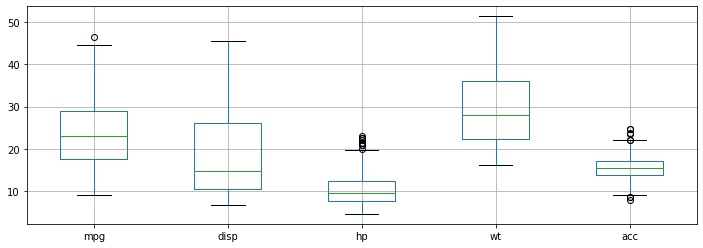

```python
mpg_box.boxplot(figsize = (12,4))
```

##### Displacement (disp), weight (wt) and Horse Power (hp) column have a long tails on the right side (above) of the distribution when compared to the left tail (bottom). The difference indicates skew in the distribution as well.

##### Let us check for skew in the distribution

```python
mpg_data.skew()
```

```
mpg       0.457066
cyl       0.526922
disp      0.719645
hp        1.097384
wt        0.531063
acc       0.278777
yr        0.011535
origin    0.923776
dtype: float64
```

##### We can observe all the skew values are postive, indicating longer right tails. disp and wt have moderate skew, hp has very high skew.

##### Origin seems to have high skew but from the describe table, we can see it is a categorical column and has only 3 values. So the skew might be an indication that one category far exceeds the others.

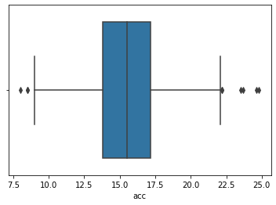

```python
sns.boxplot(mpg_data.acc)
```

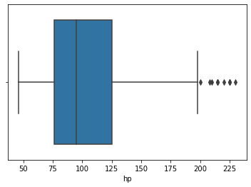

```python
sns.boxplot(mpg_data.hp)
```

##### Seems like there are outliers in hp and acc columns. Let us check out how many are there in each

```python
hp_Q3 = mpg_data.hp.quantile(.75)
hp_Q1 = mpg_data.hp.quantile(.25)
hp_IQR = hp_Q3-hp_Q1

mpg_data[(mpg_data['hp'] > hp_Q3+(1.5*hp_IQR))]
```

|  | car_name | mpg | cyl | disp | hp | wt | acc | yr | origin |
| --- | --- | --- | --- | --- | --- | --- | --- | --- | --- |
| 6 | chevrolet impala | 14.0 | 8 | 454.0 | 220.0 | 4354 | 9.0 | 70 | 1 |
| 7 | plymouth fury iii | 14.0 | 8 | 440.0 | 215.0 | 4312 | 8.5 | 70 | 1 |
| 8 | pontiac catalina | 14.0 | 8 | 455.0 | 225.0 | 4425 | 10.0 | 70 | 1 |
| 13 | buick estate wagon (sw) | 14.0 | 8 | 455.0 | 225.0 | 3086 | 10.0 | 70 | 1 |
| 25 | ford f250 | 10.0 | 8 | 360.0 | 215.0 | 4615 | 14.0 | 70 | 1 |
| 26 | chevy c20 | 10.0 | 8 | 307.0 | 200.0 | 4376 | 15.0 | 70 | 1 |
| 27 | dodge d200 | 11.0 | 8 | 318.0 | 210.0 | 4382 | 13.5 | 70 | 1 |
| 67 | mercury marquis | 11.0 | 8 | 429.0 | 208.0 | 4633 | 11.0 | 72 | 1 |
| 94 | chrysler new yorker brougham | 13.0 | 8 | 440.0 | 215.0 | 4735 | 11.0 | 73 | 1 |
| 95 | buick electra 225 custom | 12.0 | 8 | 455.0 | 225.0 | 4951 | 11.0 | 73 | 1 |
| 116 | pontiac grand prix | 16.0 | 8 | 400.0 | 230.0 | 4278 | 9.5 | 73 | 1 |

```python
acc_Q3 = mpg_data.acc.quantile(.75)
acc_Q1 = mpg_data.acc.quantile(.25)
acc_IQR = acc_Q3-acc_Q1
mpg_data[ (mpg_data['acc']> acc_Q3+(acc_IQR*1.5)) | (mpg_data['acc'] < acc_Q1-(acc_IQR*1.5))]
```

|  | car_name | mpg | cyl | disp | hp | wt | acc | yr | origin |
| --- | --- | --- | --- | --- | --- | --- | --- | --- | --- |
| 7 | plymouth fury iii | 14.0 | 8 | 440.0 | 215.0 | 4312 | 8.5 | 70 | 1 |
| 9 | amc ambassador dpl | 15.0 | 8 | 390.0 | 190.0 | 3850 | 8.5 | 70 | 1 |
| 11 | plymouth 'cuda 340 | 14.0 | 8 | 340.0 | 160.0 | 3609 | 8.0 | 70 | 1 |
| 59 | volkswagen type 3 | 23.0 | 4 | 97.0 | 54.0 | 2254 | 23.5 | 72 | 2 |
| 195 | chevrolet chevette | 29.0 | 4 | 85.0 | 52.0 | 2035 | 22.2 | 76 | 1 |
| 299 | peugeot 504 | 27.2 | 4 | 141.0 | 71.0 | 3190 | 24.8 | 79 | 2 |
| 300 | oldsmobile cutlass salon brougham | 23.9 | 8 | 260.0 | 90.0 | 3420 | 22.2 | 79 | 1 |
| 326 | vw dasher (diesel) | 43.4 | 4 | 90.0 | 48.0 | 2335 | 23.7 | 80 | 2 |
| 394 | vw pickup | 44.0 | 4 | 97.0 | 52.0 | 2130 | 24.6 | 82 | 2 |

```python
l = len(mpg_data[(mpg_data['hp'] > hp_Q3+(1.5*hp_IQR)) | (mpg_data['acc']> acc_Q3+(acc_IQR*1.5)) | (mpg_data['acc'] < acc_Q1-(acc_IQR*1.5))])
print('There are {} outliers in total.'.format(l))
```

```
There are 19 outliers in total.
```

##### Let us go with the second strat for acc column

```python
mpg_data['acc']= mpg_data['acc'].clip(lower= mpg_data['acc'].quantile(0.05), upper= mpg_data['acc'].quantile(0.95))
```

##### All our categorical variables are already labeled. We can leave them at that or use one-hot encoding if we want to remove the affect of numbers on mpg prediction.

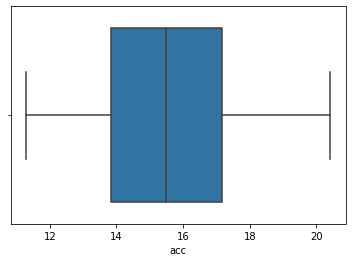

```python
sns.boxplot(mpg_data.acc)
```

## Question 3 - Data analysis & visualisation:

```python
# Perform detailed statistical analysis on the data.`
# Perform a detailed univariate, bivariate and multivariate analysis with appropriate detailed comments after each analysis.
```

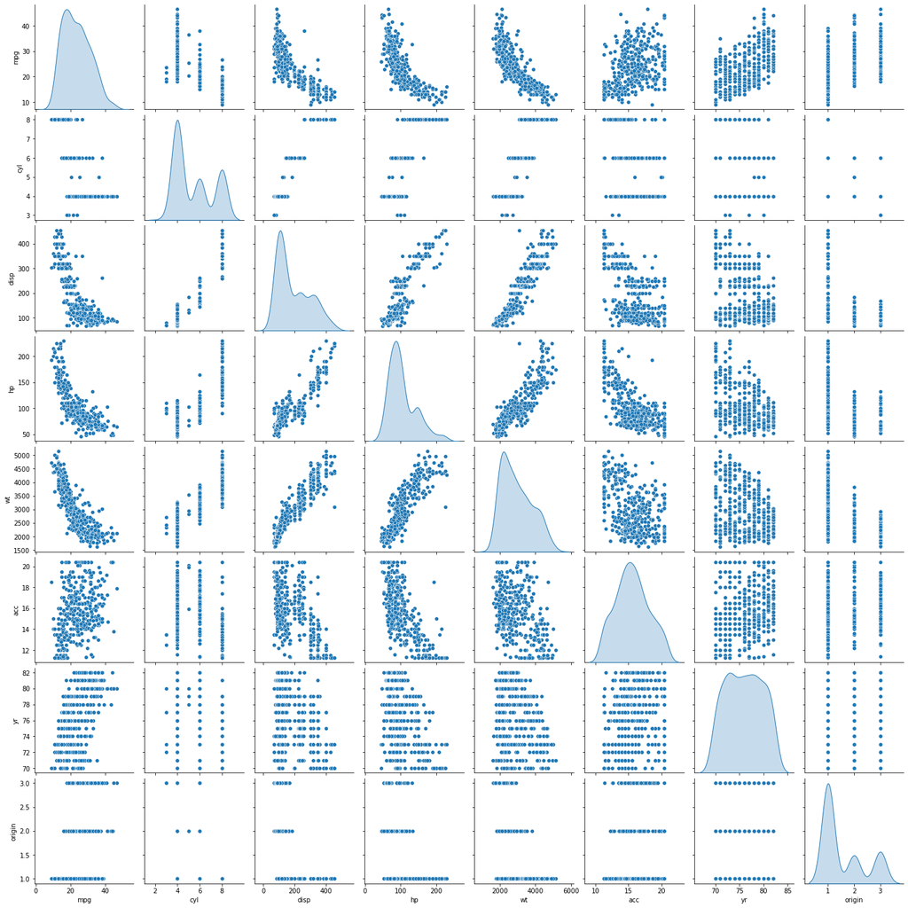

```python
sns.pairplot(mpg_data, diag_kind='kde');
```

##### Only acc seems to have a symmetric distribution.

##### yr distribution shows it is very closely distributed i.e, all the years have closely same number of cars.

##### hp, disp and wt can be seen to be strongly related.

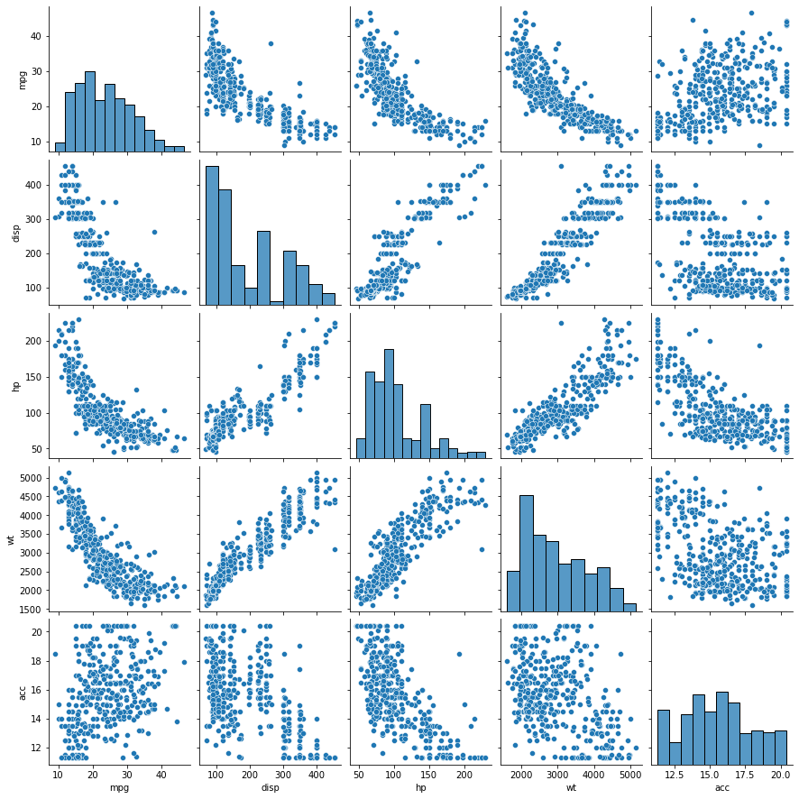

```python
sns.pairplot(mpg_data[['mpg', 'disp', 'hp', 'wt', 'acc']]);
```

##### It is very clear from the graphs that disp, wt and hp are directly proportional while mpg is inversely proportional to them. But it is also observed that the relationship is not linear.

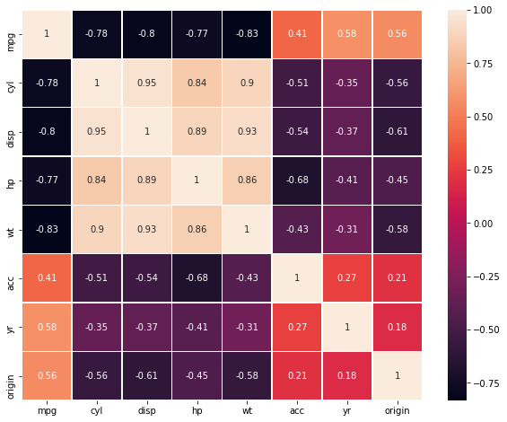

```python
corr_matrix = mpg_data.corr()
f, ax = plt.subplots(figsize=(10, 8))
sns.heatmap(corr_matrix, annot = True, ax = ax, linewidth = .5)
```

##### Let us analyse each of the columns individually and in relation to the categorical columns.

```python
mpg_data.describe().T
```

|  | count | mean | std | min | 25% | 50% | 75% | max |
| --- | --- | --- | --- | --- | --- | --- | --- | --- |
| mpg | 398.0 | 23.514573 | 7.815984 | 9.000 | 17.500 | 23.0 | 29.000 | 46.600 |
| cyl | 398.0 | 5.454774 | 1.701004 | 3.000 | 4.000 | 4.0 | 8.000 | 8.000 |
| disp | 398.0 | 193.425879 | 104.269838 | 68.000 | 104.250 | 148.5 | 262.000 | 455.000 |
| hp | 398.0 | 104.445645 | 38.199671 | 46.000 | 76.000 | 95.0 | 125.000 | 230.000 |
| wt | 398.0 | 2970.424623 | 846.841774 | 1613.000 | 2223.750 | 2803.5 | 3608.000 | 5140.000 |
| acc | 398.0 | 15.553015 | 2.469951 | 11.285 | 13.825 | 15.5 | 17.175 | 20.415 |
| yr | 398.0 | 76.010050 | 3.697627 | 70.000 | 73.000 | 76.0 | 79.000 | 82.000 |
| origin | 398.0 | 1.572864 | 0.802055 | 1.000 | 1.000 | 1.0 | 2.000 | 3.000 |

```python
print ('We have the best mpg 46.6 for the following car')
print(mpg_data[mpg_data.mpg == 46.6])
print ('\nAnd the least mpg 9.0 for the following car')
print(mpg_data[mpg_data.mpg == 9.0])
```

```
We have the best mpg 46.6 for the following car
      car_name   mpg  cyl  disp    hp    wt   acc  yr  origin
322  mazda glc  46.6    4  86.0  65.0  2110  17.9  80       3

And the least mpg 9.0 for the following car
    car_name  mpg  cyl   disp     hp    wt   acc  yr  origin
28  hi 1200d  9.0    8  304.0  193.0  4732  18.5  70       1
```

##### Distribution of Cylinders

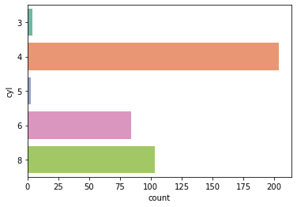

```python
sns.countplot(data=mpg_data, y = mpg_data['cyl'], palette = 'Set2')
```

##### Most of the cars are 4 cylindered

##### Let us see the relation between cylinders and mpg

```python
print('Mean values from each cylinder groups:\n' , mpg_data.groupby('cyl').mpg.mean())
print('\n\nThe max mpg of cars from each cylinder groups:\n')
mpg_data.loc[mpg_data.reset_index().groupby(['cyl'])['mpg'].idxmax()]
```

```
Mean values from each cylinder groups:
 cyl
3    20.550000
4    29.286765
5    27.366667
6    19.985714
8    14.963107
Name: mpg, dtype: float64


The max mpg of cars from each cylinder groups:
```

|  | car_name | mpg | cyl | disp | hp | wt | acc | yr | origin |
| --- | --- | --- | --- | --- | --- | --- | --- | --- | --- |
| 334 | mazda rx-7 gs | 23.7 | 3 | 70.0 | 100.0 | 2420 | 12.5 | 80 | 3 |
| 322 | mazda glc | 46.6 | 4 | 86.0 | 65.0 | 2110 | 17.9 | 80 | 3 |
| 327 | audi 5000s (diesel) | 36.4 | 5 | 121.0 | 67.0 | 2950 | 19.9 | 80 | 2 |
| 387 | oldsmobile cutlass ciera (diesel) | 38.0 | 6 | 262.0 | 85.0 | 3015 | 17.0 | 82 | 1 |
| 364 | oldsmobile cutlass ls | 26.6 | 8 | 350.0 | 105.0 | 3725 | 19.0 | 81 | 1 |

##### Cars with 4 cylinders seem to give the optimum mean mpg.

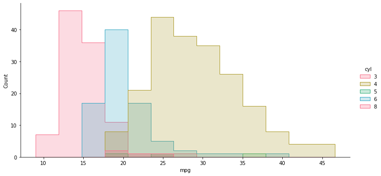

```python
sns.color_palette("pastel")
sns.displot(mpg_data, x="mpg", hue="cyl", element="step", palette = 'husl', aspect = 2);
```

##### We can see clearly that there are very few cars with 3 and 5 cylinders. But while 3 cylindered cars are in the lower mid range of mpg(18-22), 5 cylindered cars vary from 20 to 37 mpg.

##### Most of the 4 cylinder cars have higher mpgs (>22) and almost all of the 8 cylindered cars have mpgs below 18.

##### But we can see that 6 cylindered cars vary in their mpg across the spectrum, even though they are sparsely distributed in the upper range, we can still find them unlike the 8 cylindered cars.

##### Now let us include origin into the picture

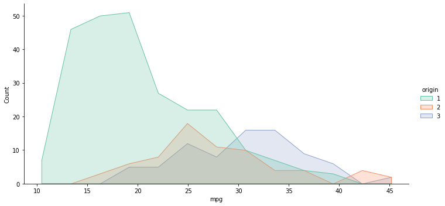

```python
sns.displot(mpg_data, x = 'mpg', hue = 'origin', element = 'poly', palette = 'Set2', aspect = 2)
```

##### Most of the cars are from Origin 1 and a major portion of the these cars have mpg less than 25.

##### Origin 2 and Origin 3 have almost same frequency distribution with Origin 3 on slightly higher mpg side.

##### Cylinders with respect to the origin

```python
pd.crosstab(mpg_data['origin'], mpg_data['cyl'], rownames=['origin'], colnames=['cyl'], margins = True)
```

| cyl origin | 3 | 4 | 5 | 6 | 8 | All |
| --- | --- | --- | --- | --- | --- | --- |
| 1 | 0 | 72 | 0 | 74 | 103 | 249 |
| 2 | 0 | 63 | 3 | 4 | 0 | 70 |
| 3 | 4 | 69 | 0 | 6 | 0 | 79 |
| All | 4 | 204 | 3 | 84 | 103 | 398 |

##### Interestingly all the 8 cylindered cars and most of the 6 cylindered are from Origin 1 which also adds to the fact observed above that Origin 1 cars have mpg < 25

##### 4 Cylindered cars come from all 3 origins almost equally.

##### 3 Cylindered cars come from only Origin 3 and 5 cylindered come from only Origin 2. They are 4 and 3 respectively which is safe to say that they are very rare.

##### mpg with respect to the origin

```python
print('The mean mpg of cars from each origin are:\n' ,mpg_data.groupby('origin').mpg.mean())
print('The max mpg of cars from each origin are:\n')
mpg_data.loc[mpg_data.reset_index().groupby(['origin'])['mpg'].idxmax()]
```

```
The mean mpg of cars from each origin are:
 origin
1    20.083534
2    27.891429
3    30.450633
Name: mpg, dtype: float64
The max mpg of cars from each origin are:
```

|  | car_name | mpg | cyl | disp | hp | wt | acc | yr | origin |
| --- | --- | --- | --- | --- | --- | --- | --- | --- | --- |
| 344 | plymouth champ | 39.0 | 4 | 86.0 | 64.0 | 1875 | 16.400 | 81 | 1 |
| 325 | vw rabbit c (diesel) | 44.3 | 4 | 90.0 | 48.0 | 2085 | 20.415 | 80 | 2 |
| 322 | mazda glc | 46.6 | 4 | 86.0 | 65.0 | 2110 | 17.900 | 80 | 3 |

##### Putting the mpg, origin and cylinders together.

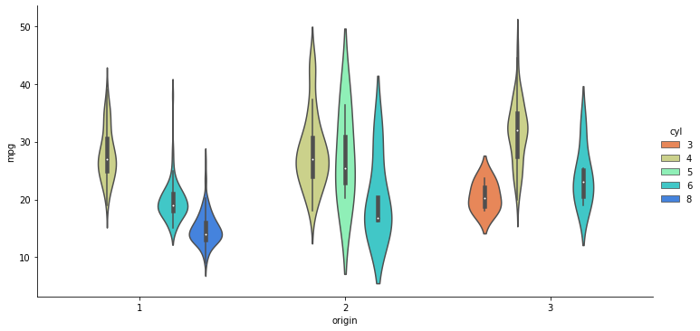

```python
sns.catplot(x="origin", y="mpg", hue="cyl", data=mpg_data, kind = 'violin', palette = 'rainbow_r', height = 5, aspect = 2);
```

##### And as we have already seen, all the 8 cylindered cars are from Origin 1 and have low mpg.

##### Let us see take a closer look at 6 cylindered cars.

```python
cyl6 = mpg_data[(mpg_data.cyl == 6)][['mpg', 'origin']]
```

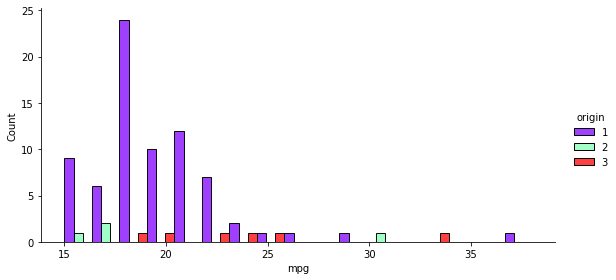

```python
sns.displot(cyl6, x= 'mpg', hue = 'origin', palette = 'rainbow', multiple = 'dodge', height = 4,  aspect = 2)
```

##### And now let us include the last categorical column - year

##### Origin with respect to year

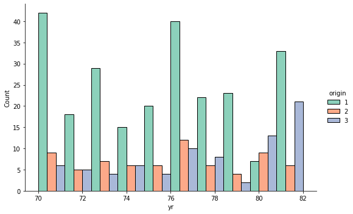

```python
sns.displot ( data = mpg_data, x = 'yr', hue = 'origin', element = 'bars', palette = 'Set2', multiple= 'dodge', height = 5, aspect = 1.5);
```

```python
pd.crosstab(mpg_data['origin'], mpg_data['yr'], rownames=['origin'], colnames=['yr'], margins = True)
```

| yr origin | 70 | 71 | 72 | 73 | 74 | 75 | 76 | 77 | 78 | 79 | 80 | 81 | 82 | All |
| --- | --- | --- | --- | --- | --- | --- | --- | --- | --- | --- | --- | --- | --- | --- |
| 1 | 22 | 20 | 18 | 29 | 15 | 20 | 22 | 18 | 22 | 23 | 7 | 13 | 20 | 249 |
| 2 | 5 | 4 | 5 | 7 | 6 | 6 | 8 | 4 | 6 | 4 | 9 | 4 | 2 | 70 |
| 3 | 2 | 4 | 5 | 4 | 6 | 4 | 4 | 6 | 8 | 2 | 13 | 12 | 9 | 79 |
| All | 29 | 28 | 28 | 40 | 27 | 30 | 34 | 28 | 36 | 29 | 29 | 29 | 31 | 398 |

##### We can see that almost same number of new cars were released every year from all origins except in the year 80 where the Origin 1 had suddenly plummetted and Origin 3 seemed to have cashed the opportunity and released more. We can see the Origin 1 recovering in the next two years.

##### Cylinders with respect to year

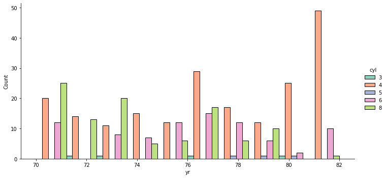

```python
sns.displot ( data = mpg_data, x = 'yr', hue = 'cyl', element = 'bars', palette = 'Set2', multiple= 'dodge', height = 5, aspect = 2);
```

```python
pd.crosstab(mpg_data['cyl'], mpg_data['yr'], rownames=['cyl'], colnames=['yr'], margins = True)
```

| yr cyl | 70 | 71 | 72 | 73 | 74 | 75 | 76 | 77 | 78 | 79 | 80 | 81 | 82 | All |
| --- | --- | --- | --- | --- | --- | --- | --- | --- | --- | --- | --- | --- | --- | --- |
| 3 | 0 | 0 | 1 | 1 | 0 | 0 | 0 | 1 | 0 | 0 | 1 | 0 | 0 | 4 |
| 4 | 7 | 13 | 14 | 11 | 15 | 12 | 15 | 14 | 17 | 12 | 25 | 21 | 28 | 204 |
| 5 | 0 | 0 | 0 | 0 | 0 | 0 | 0 | 0 | 1 | 1 | 1 | 0 | 0 | 3 |
| 6 | 4 | 8 | 0 | 8 | 7 | 12 | 10 | 5 | 12 | 6 | 2 | 7 | 3 | 84 |
| 8 | 18 | 7 | 13 | 20 | 5 | 6 | 9 | 8 | 6 | 10 | 0 | 1 | 0 | 103 |
| All | 29 | 28 | 28 | 40 | 27 | 30 | 34 | 28 | 36 | 29 | 29 | 29 | 31 | 398 |

##### mpg of cars from various origin with respect to year

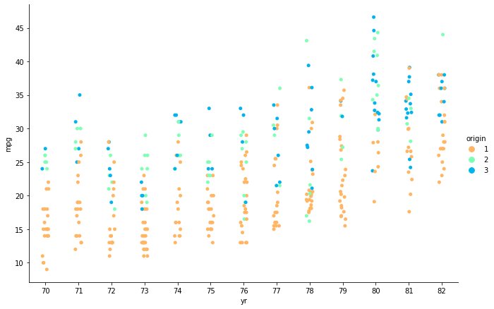

```python
sns.catplot(height = 6, aspect = 1.5, x="yr", y="mpg", hue="origin", data=mpg_data, palette = 'rainbow_r');
```

##### Origin 1 cars from early 70's have really low mileage (mpg). Slowly over the years, we can see the increase in mpg in cars from origin 1. Apart from this an increase in the overall mpg can be observed through the years.

##### Also the cars from Origin 2 and 3 seems to have upper hand when it came to mileage through out all the years.

##### For some reason, the mpg of cars even from origin 2 and 3 have gone down in the years '81 and '82 after steep rise in the year '80

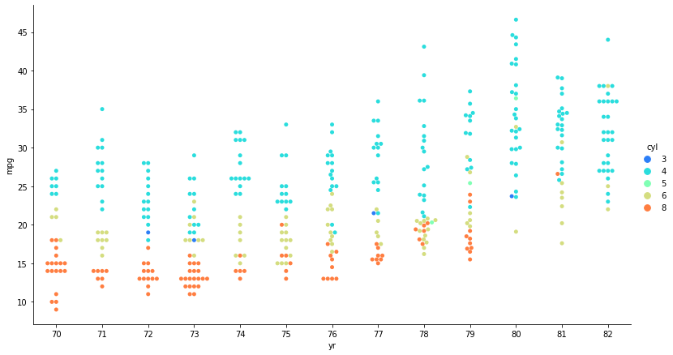

```python
sns.catplot(height = 6, aspect = 1.8, x="yr", y="mpg", hue="cyl", kind = 'swarm', data=mpg_data, palette = 'rainbow');
```

##### 4 cylindered cars have easily obtained the highest mpg from every year. Only in the year '82', one 6 cylindered car has come close competition to it.

##### We can see 8 and 6 cylndered cars continuously occupying lower mpgs every year.

##### Let us see the mean of mpg each year and compare the trend.

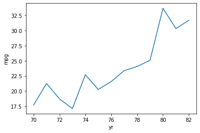

```python
sns.lineplot(x = 'yr', y = mpg_data.groupby('yr').mpg.mean(), data = mpg_data.groupby('yr').mpg.mean());
```

##### From the year '73, the mileage of the cars have been increasing and we can see sudden spike in the year '80. This can be attributed to the reduction of Origin 1 cars (especially the 8 Cylindered cars) in that year which were mostly on the lower end of the mpg spectrum.

```python
print('The cars with max mpg each from year are:')
mpg_data.loc[mpg_data.reset_index().groupby(['yr'])['mpg'].idxmax()]
```

```
The cars with max mpg each from year are:
```

|  | car_name | mpg | cyl | disp | hp | wt | acc | yr | origin |
| --- | --- | --- | --- | --- | --- | --- | --- | --- | --- |
| 18 | datsun pl510 | 27.0 | 4 | 97.0 | 88.0 | 2130 | 14.500 | 70 | 3 |
| 54 | datsun 1200 | 35.0 | 4 | 72.0 | 69.0 | 1613 | 18.000 | 71 | 3 |
| 81 | datsun 510 (sw) | 28.0 | 4 | 97.0 | 92.0 | 2288 | 17.000 | 72 | 3 |
| 117 | fiat 128 | 29.0 | 4 | 68.0 | 49.0 | 1867 | 19.500 | 73 | 2 |
| 131 | toyota corolla 1200 | 32.0 | 4 | 71.0 | 65.0 | 1836 | 20.415 | 74 | 3 |
| 181 | honda civic cvcc | 33.0 | 4 | 91.0 | 53.0 | 1795 | 17.500 | 75 | 3 |
| 198 | honda civic | 33.0 | 4 | 91.0 | 53.0 | 1795 | 17.400 | 76 | 3 |
| 218 | renault 5 gtl | 36.0 | 4 | 79.0 | 58.0 | 1825 | 18.600 | 77 | 2 |
| 244 | volkswagen rabbit custom diesel | 43.1 | 4 | 90.0 | 48.0 | 1985 | 20.415 | 78 | 2 |
| 304 | fiat strada custom | 37.3 | 4 | 91.0 | 69.0 | 2130 | 14.700 | 79 | 2 |
| 322 | mazda glc | 46.6 | 4 | 86.0 | 65.0 | 2110 | 17.900 | 80 | 3 |
| 343 | toyota starlet | 39.1 | 4 | 79.0 | 58.0 | 1755 | 16.900 | 81 | 3 |
| 394 | vw pickup | 44.0 | 4 | 97.0 | 52.0 | 2130 | 20.415 | 82 | 2 |

##### There is not even one car from Origin 1 that has topped in mpg from any year. And as expected all are 4 cylindered cars that have topped each year.

```python
print('The cars with least mpg each from year are:')
mpg_data.loc[mpg_data.groupby('yr').mpg.idxmin()]
```

```
The cars with least mpg each from year are:
```

|  | car_name | mpg | cyl | disp | hp | wt | acc | yr | origin |
| --- | --- | --- | --- | --- | --- | --- | --- | --- | --- |
| 28 | hi 1200d | 9.0 | 8 | 304.0 | 193.0 | 4732 | 18.500 | 70 | 1 |
| 42 | dodge monaco (sw) | 12.0 | 8 | 383.0 | 180.0 | 4955 | 11.500 | 71 | 1 |
| 67 | mercury marquis | 11.0 | 8 | 429.0 | 208.0 | 4633 | 11.285 | 72 | 1 |
| 103 | chevrolet impala | 11.0 | 8 | 400.0 | 150.0 | 4997 | 14.000 | 73 | 1 |
| 137 | buick century luxus (sw) | 13.0 | 8 | 350.0 | 150.0 | 4699 | 14.500 | 74 | 1 |
| 166 | ford mustang ii | 13.0 | 8 | 302.0 | 129.0 | 3169 | 12.000 | 75 | 1 |
| 208 | plymouth volare premier v8 | 13.0 | 8 | 318.0 | 150.0 | 3940 | 13.200 | 76 | 1 |
| 224 | mercury cougar brougham | 15.0 | 8 | 302.0 | 130.0 | 4295 | 14.900 | 77 | 1 |
| 277 | peugeot 604sl | 16.2 | 6 | 163.0 | 133.0 | 3410 | 15.800 | 78 | 2 |
| 290 | ford country squire (sw) | 15.5 | 8 | 351.0 | 142.0 | 4054 | 14.300 | 79 | 1 |
| 316 | dodge aspen | 19.1 | 6 | 225.0 | 90.0 | 3381 | 18.700 | 80 | 1 |
| 366 | chrysler lebaron salon | 17.6 | 6 | 225.0 | 85.0 | 3465 | 16.600 | 81 | 1 |
| 389 | ford granada l | 22.0 | 6 | 232.0 | 112.0 | 2835 | 14.700 | 82 | 1 |

##### All the cars that have least mpg every year belong to Origin 1 and have 6/8 cylinders. Only in the year '78, a car from origin 2 and 6 cyl has the least mpg.

##### Let us ready two functions that can give the overall proportion of a categorical variable and the propotion of a categorical vairable with respect to another categorical variable.

```python
def OverallProportion (col_name, prop_of):
    x = mpg_data[col_name].value_counts()
    return round(x[prop_of]/sum(x), 4)

def GroupbyProportion(group_by, col_name, group_of, prop_of):
    x = mpg_data.groupby(group_by)[col_name].value_counts()
    return round(x[group_of][prop_of]/sum(x[group_of]), 4)

#col_name - which column we need proportion of
#prop_of - which value in the col_name we need the proportion of
#group_by - which column to group by
#group_of - wrt which value of the group the proportion is required
```

```python
OverallProportion('cyl', 8)
```

```
0.2588
```

```python
GroupbyProportion('origin', 'cyl', 1, 4 )
```

```
0.2892
```

```python
GroupbyProportion('yr', 'origin', 80, 1 )
```

```
0.2414
```

##### Proportions of Origins and Cylinders

```python
for origin in [1,2,3]:
    print ('The proportion of origin {} cars is {}'.format(origin, OverallProportion('origin', origin)) )
```

```
The proportion of origin 1 cars is 0.6256
The proportion of origin 2 cars is 0.1759
The proportion of origin 3 cars is 0.1985
```

##### This is a huge difference (more than 300% difference) in the proportions of cars from Origin 1 when compared to Origin 2 and 3

```python
for cyl in mpg_data.cyl.unique():
    print ('The proportion of {} cylindered cars is {}'.format(cyl, OverallProportion('cyl', cyl)) )
```

```
The proportion of 8 cylindered cars is 0.2588
The proportion of 4 cylindered cars is 0.5126
The proportion of 6 cylindered cars is 0.2111
The proportion of 3 cylindered cars is 0.0101
The proportion of 5 cylindered cars is 0.0075
```

##### 51% of the new cars coming to market is occupied by 4 cylindered cars alone

##### Cylinders vs years

```python
for cyl in mpg_data.cyl.unique():
    print('\n')
    for yr in mpg_data.yr.unique():
        try:
            prop = GroupbyProportion('yr', 'cyl', yr, cyl )
            print('The proportion of {} Cylindered cars from the year {} was {}'.format(cyl, yr, prop))
        except KeyError:
            print('No {} cylindered cars from the year {}'.format(cyl, yr))
```

```
The proportion of 8 Cylindered cars from the year 70 was 0.6207
The proportion of 8 Cylindered cars from the year 71 was 0.25
The proportion of 8 Cylindered cars from the year 72 was 0.4643
The proportion of 8 Cylindered cars from the year 73 was 0.5
The proportion of 8 Cylindered cars from the year 74 was 0.1852
The proportion of 8 Cylindered cars from the year 75 was 0.2
The proportion of 8 Cylindered cars from the year 76 was 0.2647
The proportion of 8 Cylindered cars from the year 77 was 0.2857
The proportion of 8 Cylindered cars from the year 78 was 0.1667
The proportion of 8 Cylindered cars from the year 79 was 0.3448
No 8 cylindered cars from the year 80
The proportion of 8 Cylindered cars from the year 81 was 0.0345
No 8 cylindered cars from the year 82


The proportion of 4 Cylindered cars from the year 70 was 0.2414
The proportion of 4 Cylindered cars from the year 71 was 0.4643
The proportion of 4 Cylindered cars from the year 72 was 0.5
The proportion of 4 Cylindered cars from the year 73 was 0.275
The proportion of 4 Cylindered cars from the year 74 was 0.5556
The proportion of 4 Cylindered cars from the year 75 was 0.4
The proportion of 4 Cylindered cars from the year 76 was 0.4412
The proportion of 4 Cylindered cars from the year 77 was 0.5
The proportion of 4 Cylindered cars from the year 78 was 0.4722
The proportion of 4 Cylindered cars from the year 79 was 0.4138
The proportion of 4 Cylindered cars from the year 80 was 0.8621
The proportion of 4 Cylindered cars from the year 81 was 0.7241
The proportion of 4 Cylindered cars from the year 82 was 0.9032


The proportion of 6 Cylindered cars from the year 70 was 0.1379
The proportion of 6 Cylindered cars from the year 71 was 0.2857
No 6 cylindered cars from the year 72
The proportion of 6 Cylindered cars from the year 73 was 0.2
The proportion of 6 Cylindered cars from the year 74 was 0.2593
The proportion of 6 Cylindered cars from the year 75 was 0.4
The proportion of 6 Cylindered cars from the year 76 was 0.2941
The proportion of 6 Cylindered cars from the year 77 was 0.1786
The proportion of 6 Cylindered cars from the year 78 was 0.3333
The proportion of 6 Cylindered cars from the year 79 was 0.2069
```

[output cut: 18 more lines]

```


No 5 cylindered cars from the year 70
No 5 cylindered cars from the year 71
No 5 cylindered cars from the year 72
No 5 cylindered cars from the year 73
No 5 cylindered cars from the year 74
No 5 cylindered cars from the year 75
No 5 cylindered cars from the year 76
No 5 cylindered cars from the year 77
The proportion of 5 Cylindered cars from the year 78 was 0.0278
The proportion of 5 Cylindered cars from the year 79 was 0.0345
The proportion of 5 Cylindered cars from the year 80 was 0.0345
No 5 cylindered cars from the year 81
No 5 cylindered cars from the year 82
```

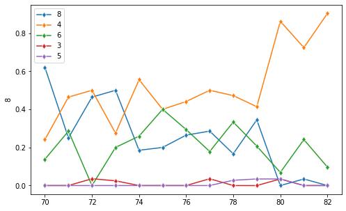

```python
cyl_dict = {}
for cyl in mpg_data.cyl.unique():
    cyl_dict[str(cyl)] = []
    for yr in mpg_data.yr.unique():
        try:
            prop = GroupbyProportion('yr', 'cyl', yr, cyl )
            cyl_dict[str(cyl)].append(prop)
        except KeyError:
            cyl_dict[str(cyl)].append(0)
cyl_df = pd.DataFrame(cyl_dict, index = mpg_data.yr.unique())
fig, ax = plt.subplots(figsize=(8,5))
for cyl in mpg_data.cyl.unique():
    sns.lineplot(ax= ax ,x = cyl_df.index , y = cyl_df[str(cyl)], label = cyl, marker = 'd');
```

##### No discernable trends with respect to the cylinders across the years. We can just say that the proportion of 4 cylindered cars has increased drastically and 8 cylindered cars has plummetted during the passing of these years.

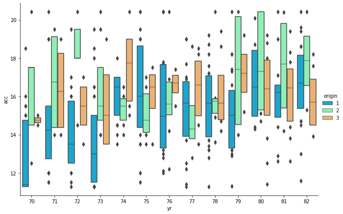

```python
sns.catplot(height = 6, aspect = 1.5, x="yr", y="acc", hue = 'origin', kind = 'boxen', data=mpg_data, palette = 'rainbow');
```

##### The acceleration of cars from Origin 1 did not vary much for the early 70's which slowly spread across the entire spectrum by '76 and again the variation reduced but we can see the boxes move towards higher acceleration

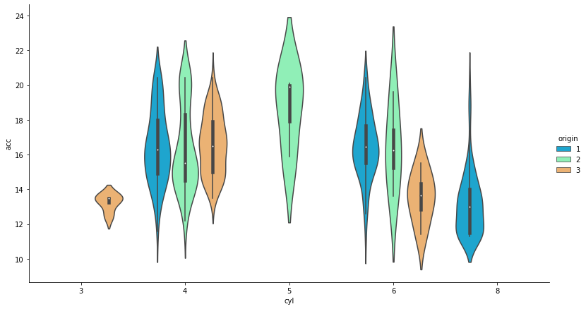

```python
sns.catplot(height = 6, aspect = 1.8, x="cyl", y="acc", hue="origin", data=mpg_data, palette = 'rainbow' ,kind = 'violin');
```

##### In the 4 cylindered cars the acc is distributed similarly in all 3 origins.

##### All the 5 cylindered cars are of origin 2 and have acc mostly have acc above 16.5

##### In the 6 cylindered cars, the variation in acc is across the spectrum in cars from origin 2 while cars from origin 3 have acc on the lower side.

##### In the 8 cylindered cars, the acc is almost on the lower side (13-14) and one or two cars with higher acc

##### Let us see the trend of mean accelerations each year

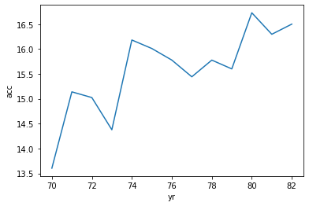

```python
sns.lineplot(x = 'yr', y = mpg_data.groupby('yr').acc.mean(), data = mpg_data.groupby('yr').acc.mean());
```

##### Overall mean of acc increased greatly from '70 to '82 with a steep increase for the year '74 and then again gradual decrease till '79 and greatly increased for '80

```python
mpg_data.groupby('origin').mean()
```

| origin | mpg | cyl | disp | hp | wt | acc | yr |
| --- | --- | --- | --- | --- | --- | --- | --- |
| 1 | 20.083534 | 6.248996 | 245.901606 | 118.789469 | 3361.931727 | 15.095723 | 75.610442 |
| 2 | 27.891429 | 4.157143 | 109.142857 | 81.196985 | 2423.300000 | 16.489286 | 75.814286 |
| 3 | 30.450633 | 4.101266 | 102.708861 | 79.835443 | 2221.227848 | 16.164747 | 77.443038 |

##### While the mean values of disp, hp, wt of cars from origin 2 and 3 are very close and considerably low in comparison to cars from origin 1, their acc mean is higher than that of cars from origin 1.

```python
mpg_data.groupby('cyl').mean()
```

| cyl | mpg | disp | hp | wt | acc | yr | origin |
| --- | --- | --- | --- | --- | --- | --- | --- |
| 3 | 20.550000 | 72.500000 | 99.250000 | 2398.500000 | 13.250000 | 75.500000 | 3.000000 |
| 4 | 29.286765 | 109.796569 | 78.884668 | 2308.127451 | 16.477157 | 77.073529 | 1.985294 |
| 5 | 27.366667 | 145.000000 | 82.333333 | 3103.333333 | 18.633333 | 79.000000 | 2.000000 |
| 6 | 19.985714 | 218.142857 | 101.522553 | 3198.226190 | 16.242202 | 75.928571 | 1.190476 |
| 8 | 14.963107 | 345.009709 | 158.300971 | 4114.718447 | 13.160340 | 73.902913 | 1.000000 |

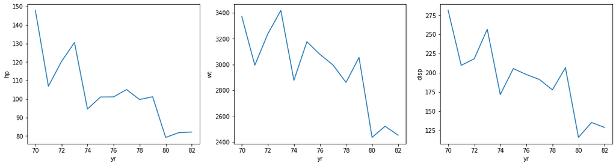

```python
plt.figure(figsize = (18,15))

plt.subplot(3,3,1)
sns.lineplot(x = 'yr', y = mpg_data.groupby('yr').hp.mean(), data = mpg_data.groupby('yr').hp.mean());

plt.subplot(3,3,2)
sns.lineplot(x = 'yr', y = mpg_data.groupby('yr').wt.mean(), data = mpg_data.groupby('yr').wt.mean());

plt.subplot(3,3,3)
sns.lineplot(x = 'yr', y = mpg_data.groupby('yr').disp.mean(), data = mpg_data.groupby('yr').disp.mean());
```

##### As expected we can see the similar trend in all three for all years since they are strongly correlated.

##### The mean values have plummetted across the years with a sharp rise in the year '73 and steep fall in the year '80.

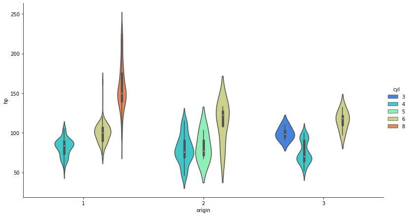

```python
sns.catplot(height = 6, aspect = 1.8, x="origin", y="hp", hue="cyl", kind = 'violin', data=mpg_data, palette = 'rainbow');
```

##### 8 Cylindered cars have very high hp when compared to other cars. And also the hp varies from almost the lowest to highest, while 4 cylindered cars from origin 1 have the lowest and closely packed values.

##### 4 and 5 cylindered cars from origin 2 have similar distribution of hp.

##### Oddly 3 cylindered cars have higher hp than most of the 4 cylindered cars.

##### We can rightly guess similar trends in weight and displacement with respect to cylinders and origins.

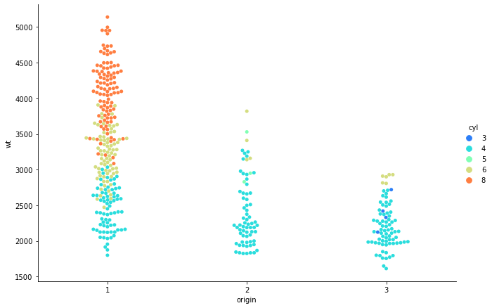

```python
sns.catplot(height = 6, aspect = 1.5, x="origin", y="wt", hue="cyl", kind = 'swarm', data=mpg_data, palette = 'rainbow');
```

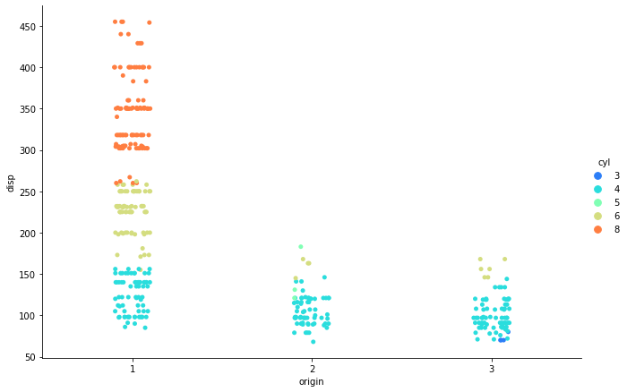

```python
sns.catplot(height = 6, aspect = 1.5, x="origin", y="disp", hue="cyl", kind = 'strip', data=mpg_data, palette = 'rainbow');
```

##### The only exception is that 3 cylindered cars have lowest displacement even though they have higher hp and wt (this is contrary to our observation that hp and disp are positively correlated)

```python
mpg_num = mpg_data.drop(['car_name', 'origin', 'yr'], axis = 1)
mpg_num['dispercyl'] = mpg_num['disp']/mpg_num['cyl']
mpg_num['hpercyl'] = mpg_num['hp']/mpg_num['cyl']
mpg_num['disptohp'] = mpg_num['disp']/mpg_num['hp']
```

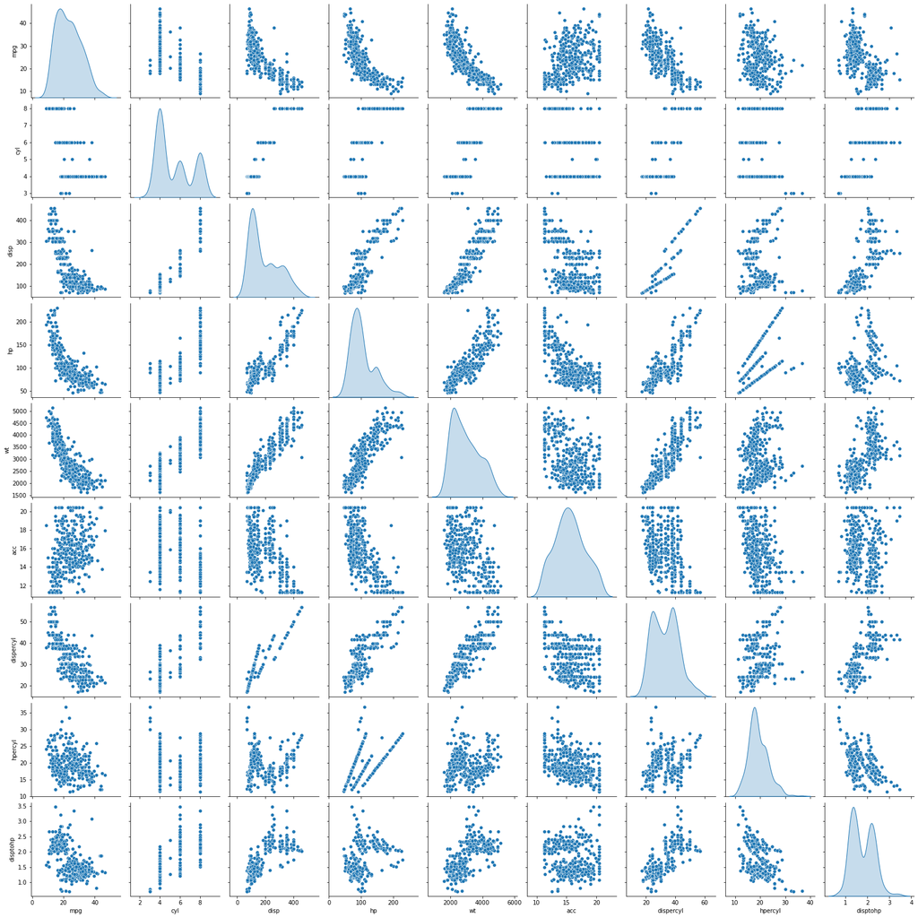

```python
sns.pairplot(mpg_num, diag_kind = 'kde');
```

##### There are no new apparent trends in the engineered features but we can see that disp per cyl is giving clear clusters. It might be a good option to include them while doing clustering

#### Question 4. Machine learning:

```python
# Use K Means and Hierarchical clustering to find out the optimal number of clusters in the data.
# Share your insights about the difference in using these two methods.
```

##### K Means clustering

```python
from scipy.stats import zscore


mpg_ = mpg_data.drop(['car_name', 'origin'], axis = 1)
# mpg_['disppercyl'] = mpg_['disp']/mpg_['cyl']
mpg_z = mpg_.apply(zscore)
```

```python
# From the pairplots, we can expect a min of 3 clusters. Let us consider 9 max clusters for now and check the inertia
from sklearn.cluster import KMeans

cluster_range = range(2, 10)
inertia_ = []

for num_clusters in cluster_range:
    clusters = KMeans( num_clusters, n_init = 5)
    clusters.fit(mpg_z)
    labels = clusters.labels_
    centroids = clusters.cluster_centers_
    inertia_.append( clusters.inertia_ )
clusters_df = pd.DataFrame( { "num_clusters":cluster_range, "inertia": inertia_ } )
clusters_df
```

|  | num_clusters | inertia |
| --- | --- | --- |
| 0 | 2 | 1290.425735 |
| 1 | 3 | 941.749198 |
| 2 | 4 | 734.128078 |
| 3 | 5 | 657.661918 |
| 4 | 6 | 590.103845 |
| 5 | 7 | 538.912850 |
| 6 | 8 | 491.944500 |
| 7 | 9 | 462.335213 |

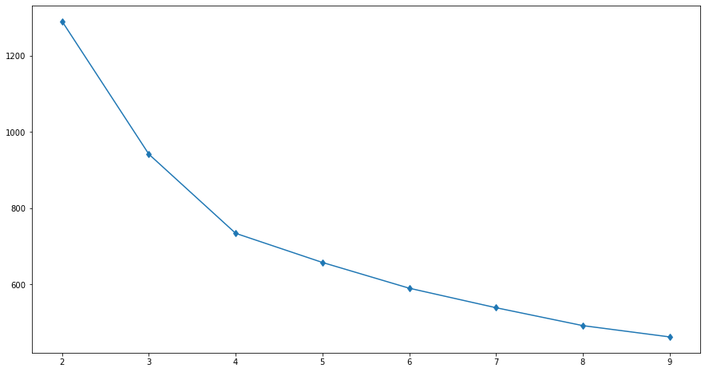

```python
plt.figure(figsize=(15,8))
plt.plot(clusters_df.num_clusters, clusters_df.inertia, marker = "d" )
```

```python
# Significant drop of inertia at k = 3
km_model = KMeans(n_clusters=3, n_init = 5)
km_model.fit(mpg_z)
mpg_labels = km_model.predict(mpg_z)
mpg_z['Label'] = mpg_labels
```

```python
mpg_z.head()
```

|  | mpg | cyl | disp | hp | wt | acc | yr | Label |
| --- | --- | --- | --- | --- | --- | --- | --- | --- |
| 0 | -0.706439 | 1.498191 | 1.090604 | 0.669810 | 0.630870 | -1.440307 | -1.627426 | 0 |
| 1 | -1.090751 | 1.498191 | 1.503514 | 1.587201 | 0.854333 | -1.642995 | -1.627426 | 0 |
| 2 | -0.706439 | 1.498191 | 1.196232 | 1.194034 | 0.550470 | -1.730151 | -1.627426 | 0 |
| 3 | -0.962647 | 1.498191 | 1.061796 | 1.194034 | 0.546923 | -1.440307 | -1.627426 | 0 |
| 4 | -0.834543 | 1.498191 | 1.042591 | 0.931922 | 0.565841 | -1.730151 | -1.627426 | 0 |

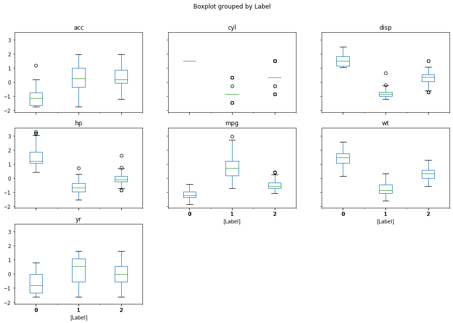

```python
mpg_z.boxplot(by='Label',layout=(3,3),figsize=(15,10),grid=False);
```

```python
mpg_data['Label'] = mpg_labels
print(mpg_data.Label.value_counts())
```

```
1    208
2     95
0     95
Name: Label, dtype: int64
```

##### Cluster 0 seems to be 'big' cars (might be SUVs) with high horse power and weight but low mpg. While cluster 2 seems like sedans (medium size) with lesser weight and horsepower but better mpg. Which leads us to cluster 1 which are the small cars (mostly hatchbacks) with least weights and power but give high mileage.

##### Hierarchial Clustering

```python
mpg_z2 = mpg_z.drop(['Label'], axis = 1)
```

```python
from sklearn.cluster import AgglomerativeClustering

agg_model = AgglomerativeClustering(n_clusters=3,affinity = 'euclidean',linkage='ward')
```

```python
agg_model.fit(mpg_z2)
```

```
AgglomerativeClustering(n_clusters=3)
```

```python
from scipy.cluster.hierarchy import cophenet, dendrogram, linkage
from scipy.spatial.distance import pdist

avl= linkage(mpg_z2,'ward')
```

```python
c, coph_dist=cophenet(avl,pdist(mpg_z2))
print('Cophenetic coefficient :',c)
```

```
Cophenetic coefficient : 0.7812859633976658
```

##### Based on the highest Cophenetic coefficient, I chose ward linkage after trying all 4 (complete, single , ward and average)

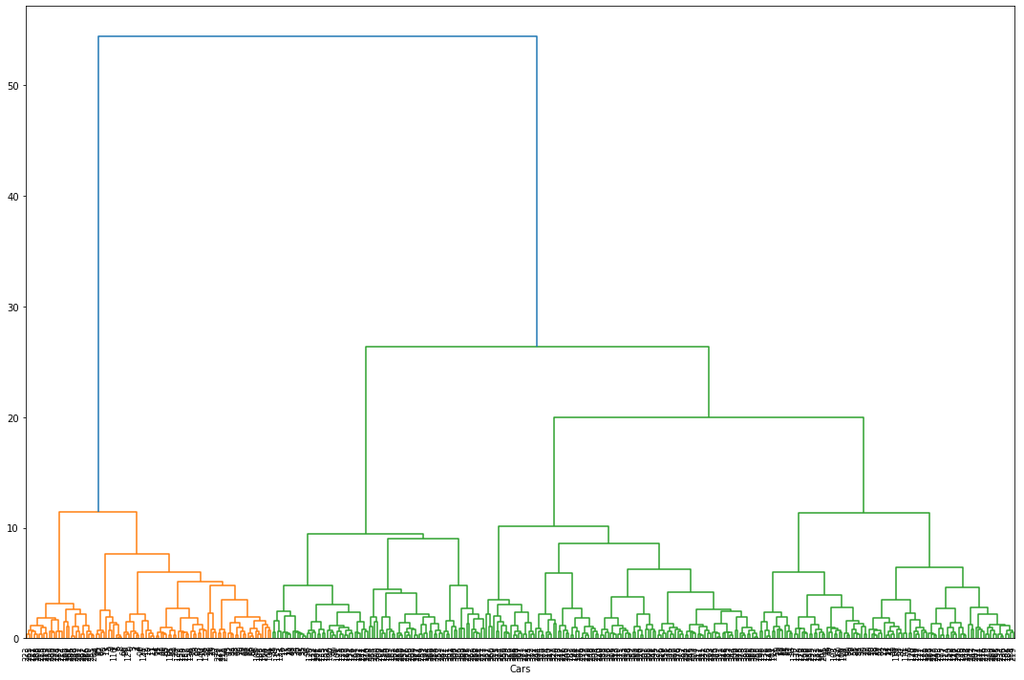

```python
plt.figure(figsize=(15,10))

plt.xlabel('Cars')

dendrogram(avl, leaf_rotation=90,  leaf_font_size= 8. )
plt.tight_layout()
```

```python
mpg_z2['label'] = agg_model.labels_
```

```python
mpg_z2.label.value_counts()
```

```
0    213
1     99
2     86
Name: label, dtype: int64
```

##### The result of the dendogram is similar to that of the KMeans. But on inspecting the dendogram there is also a possibility for a hidden 4th cluster if we take the threshold between 15-20. This clearly demonstrate the advantage of using the hierarchial clusters i.e, since we are able to visualise the formation of clusters, we are able to see for the hidden patterns in the clusters which would be oblivious to us in methods like K Means.

##### Also from the inertia graph, 3 and 4 both were possible clusters.

##### Let us go ahead with 3 clusters as suggested by the drop in inertia.

##### The numbers of labels are very close to the clusters from the KMeans clustering. Let us take a look at the boxplots

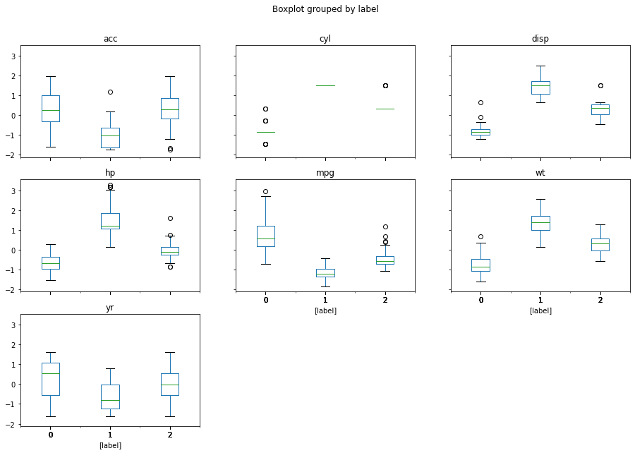

```python
mpg_z2.boxplot(by='label',layout=(3,3),figsize=(15,10),grid=False);
```

##### Cluster 0 seems to be the small cars, Cluster 2 seems to be the sedans and Cluster 1 seems to be the big cars. There is lesser overlapping in hierarchial clustering than in K Means

```python
def hue_regplot(data, x, y, hue, palette=None, **kwargs):
    regplots = []
    levels = data[hue].unique()

    for key in levels:
        regplots.append(sns.regplot(x=x,y=y,data=data[data[hue] == key],**kwargs))

    return regplots
```

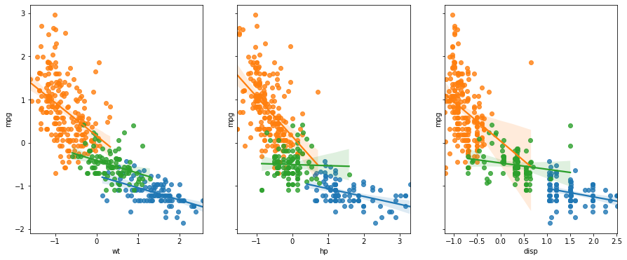

```python
f, (ax1, ax2, ax3) = plt.subplots(1,3, sharey= True, figsize = (15,6))

hue_regplot(data=mpg_z, x='wt', y='mpg', hue='Label', ax=ax1);
hue_regplot(data=mpg_z, x='hp', y='mpg', hue='Label', ax=ax2);
hue_regplot(data=mpg_z, x='disp', y='mpg', hue='Label', ax=ax3);
```

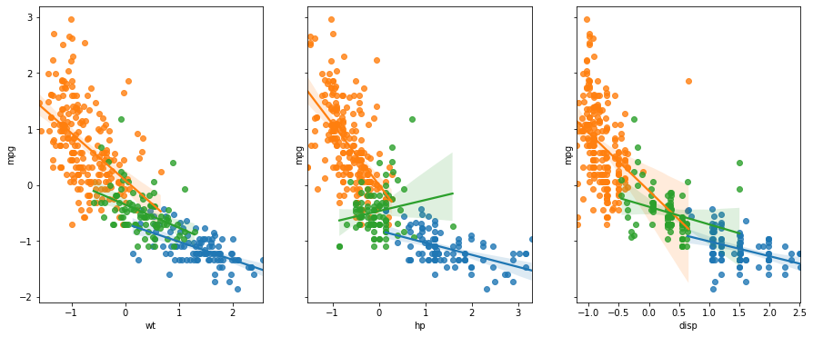

```python
f, (ax1, ax2, ax3) = plt.subplots(1,3, sharey= True, figsize = (15,6))

hue_regplot(data=mpg_z2, x='wt', y='mpg', hue='label', ax=ax1);
hue_regplot(data=mpg_z2, x='hp', y='mpg', hue='label', ax=ax2);
hue_regplot(data=mpg_z2, x='disp', y='mpg', hue='label', ax=ax3);
```

##### There seems to be a slightly less overlapping with hierarchial clustering than for KMeans. Let us go ahead and divide the clusters based on hierarchial clustering. Also a cophenetic co-efficient of .78 is a very good indicator of natural clusters

##### Question 5 - Using ML based methods

```python
# • Mention how many optimal clusters are present in the data and what could be the possible reason behind it.
# • Use linear regression model on different clusters separately and print the coefficients of the models individually
# • How using different models for different clusters will be helpful in this case and how it will be different than using
# one single model without clustering? Mention how it impacts performance and prediction.
```

##### The reason behind the 3 clusters in the data might be because of the actual scenario where the cars are manufactured based on three basic types:

1. The Hatchbacks
2. The Sedans
3. The SUVs

##### On closely inspecting how the clusters are divided, the weight and horsepower distribution in the 3 clusters suggest that the clusters are mostly divided on these types.

##### Let us go ahead and add Labels to our original data and divide it into 3 dataframes for our regression model.

```python
mpg_data['Agg_label'] = agg_model.labels_
```

```python
small_cars = mpg_data[mpg_data['Agg_label'] == 0]
sedan_cars = mpg_data[mpg_data['Agg_label'] == 2]
big_cars = mpg_data[mpg_data['Agg_label'] == 1]
```

##### For Small Cars

```python
from sklearn.model_selection import train_test_split
small_x = small_cars.drop(['car_name', 'mpg', 'Agg_label', 'Label', 'origin'], axis = 1)
small_y = small_cars['mpg']
small_x_train, small_x_test, small_y_train, small_y_test = train_test_split(small_x, small_y, test_size = .3, random_state = 24)
```

```python
from sklearn.linear_model import LinearRegression
small_model = LinearRegression()
small_model.fit(small_x_train, small_y_train)
```

```
LinearRegression()
```

```python
coef = small_model.coef_
print('The intercept for the model is {}\n'.format(small_model.intercept_))
print('The coefficents of the columns are: \n')
pd.DataFrame(coef, index = small_x.columns, columns=['co-efficent']).T
```

```
The intercept for the model is -33.0986173004084

The coefficents of the columns are:
```

|  | cyl | disp | hp | wt | acc | yr |
| --- | --- | --- | --- | --- | --- | --- |
| co-efficent | 4.229577 | -0.041705 | -0.056117 | -0.00633 | -0.135005 | 0.923146 |

```python
print('Training score for small cars :',small_model.score(small_x_train,small_y_train))
print('Test score for small cars:',small_model.score(small_x_test,small_y_test))
```

```
Training score for small cars : 0.6741308259758367
Test score for small cars: 0.7192750525022436
```

##### For Sedan Cars

```python
sedan_x = sedan_cars.drop(['car_name', 'mpg', 'Agg_label', 'Label', 'origin'], axis = 1)
sedan_y = sedan_cars['mpg']
sedan_x_train, sedan_x_test, sedan_y_train, sedan_y_test = train_test_split(sedan_x, sedan_y, test_size = .3, random_state = 24 )
```

```python
sedan_model = LinearRegression()
sedan_model.fit(sedan_x_train, sedan_y_train)
```

```
LinearRegression()
```

```python
coef = sedan_model.coef_
print('The intercept for the model is {}\n'.format(sedan_model.intercept_))
print('The coefficents of the columns are: \n')
pd.DataFrame(coef, index = sedan_x.columns, columns=['co-efficent']).T
```

```
The intercept for the model is -10.025463122571072

The coefficents of the columns are:
```

|  | cyl | disp | hp | wt | acc | yr |
| --- | --- | --- | --- | --- | --- | --- |
| co-efficent | 2.477807 | 0.000089 | -0.045141 | -0.003249 | -0.534597 | 0.50701 |

```python
print('Training score for sedan cars :',sedan_model.score(sedan_x_train,sedan_y_train))
print('Test score for sedan cars:',sedan_model.score(sedan_x_test,sedan_y_test))
```

```
Training score for sedan cars : 0.6687400935342674
Test score for sedan cars: 0.45850192536404966
```

##### For big cars

```python
big_x = big_cars.drop(['car_name', 'mpg', 'Agg_label', 'Label', 'origin'], axis = 1)
big_y = big_cars['mpg']
big_x_train, big_x_test, big_y_train, big_y_test = train_test_split(big_x, big_y, test_size = .3, random_state = 10)
```

```python
big_model = LinearRegression()
big_model.fit(big_x_train, big_y_train)
```

```
LinearRegression()
```

```python
coef = big_model.coef_
print('The intercept for the model is {}\n'.format(big_model.intercept_))
print('The coefficents of the columns are: \n')
pd.DataFrame(coef, index = big_x.columns, columns=['co-efficent']).T
```

```
The intercept for the model is 3.844015703291177

The coefficents of the columns are:
```

|  | cyl | disp | hp | wt | acc | yr |
| --- | --- | --- | --- | --- | --- | --- |
| co-efficent | 0.0 | 0.008087 | -0.035292 | -0.002035 | -0.196076 | 0.333782 |

```python
print('Training score for big cars :',big_model.score(big_x_train,big_y_train))
print('Test score for big cars:',big_model.score(big_x_test,big_y_test))
```

```
Training score for big cars : 0.6457060295365757
Test score for big cars: 0.33277220243185546
```

##### For the overall data

```python
total_x = mpg_data.drop(['car_name', 'mpg', 'Agg_label', 'Label', 'origin'], axis = 1)
total_y = mpg_data['mpg']
total_x_train, total_x_test, total_y_train, total_y_test = train_test_split(total_x, total_y, test_size = .3, random_state = 24)
```

```python
total_model = LinearRegression()
total_model.fit(total_x_train, total_y_train)
```

```
LinearRegression()
```

```python
coef = total_model.coef_
print('The intercept for the model is {}\n'.format(total_model.intercept_))
print('The coefficents of the columns are: \n')
pd.DataFrame(coef, index = total_x.columns, columns=['co-efficent']).T
```

```
The intercept for the model is -4.474891321503417

The coefficents of the columns are:
```

|  | cyl | disp | hp | wt | acc | yr |
| --- | --- | --- | --- | --- | --- | --- |
| co-efficent | -0.502679 | 0.008731 | -0.011212 | -0.006707 | -0.091236 | 0.679116 |

```python
print('Training score for total cars :',total_model.score(total_x_train,total_y_train))
print('Test score for total cars:',total_model.score(total_x_test,total_y_test))
```

```
Training score for total cars : 0.8252559078283329
Test score for total cars: 0.7537470269215856
```

##### The performance of individual models is way worse than the overall model. This is most like due to splitting the data further which has induced curse of dimensionality.

##### In this particular case, splitting the data into clusters to do regression analysis for mpg is not helpful. It affects the performance of the models in a negative manner

##### But there is another aspect to consider here:

##### Let us compare the co-efficents of all 4 models

```python
pd.DataFrame({'small_cars': small_model.coef_, 'sedan_cars': sedan_model.coef_, 'big_cars': big_model.coef_, 'total_cars': total_model.coef_}, index = small_x.columns).T
```

|  | cyl | disp | hp | wt | acc | yr |
| --- | --- | --- | --- | --- | --- | --- |
| small_cars | 4.229577 | -0.041705 | -0.056117 | -0.006330 | -0.135005 | 0.923146 |
| sedan_cars | 2.477807 | 0.000089 | -0.045141 | -0.003249 | -0.534597 | 0.507010 |
| big_cars | 0.000000 | 0.008087 | -0.035292 | -0.002035 | -0.196076 | 0.333782 |
| total_cars | -0.502679 | 0.008731 | -0.011212 | -0.006707 | -0.091236 | 0.679116 |

#### It is very clear that the coefficients are different for each cluster. This implies that the relationship between mpg and various features are different for different clusters. So it is the correct strategy to form clusters and apply regression model to individual clusters.

#### However, since the lack of 'quantity' of data, we are unable to use to this strategy as splitting the data further introduces curse of dimensionality into the datasets.

##### Question 6 - Improvisation:

```python
# Detailed suggestions or improvements or on quality, quantity, variety, velocity, veracity etc. on the data points collected by the company
# to perform a better data analysis in future.
```

##### Firstly the model might perform better if there is a lot more data available ($Quantity$ of data). We observed some outliers in the data in regards to columns hp and acc, this may be due to unreliable source for data collection or due to entries of some rare cars that affected the $Quality$ of the data. $Variety$ and $Velocity$ does not impact much in this particular case as we are not doing any real time analyses.

##### Speaking of the models used, from the early multivariate analyses, we observed that the mpg is strongly correlated to weight, horsepower and displacement.We also observed from the graphs (regplots) drawn after the clustering is done and also the initial pairplots, that this relationship is $not$ $linear$ and hence we may expect to see better results if we use a model other than linear regression (like $quadriatic$ $linear$ $regression$).